# Module Six Activity

## Create Visualizations

```python
def create_correlation_heatmap(data):
    print("Aggregating total deaths by country...")
    # To Do: Aggregate total deaths by country
    country_totals = data.drop(columns=['date']).max()

    print("Selecting top 10 countries by total deaths...")
    # To Do: Select the top 10 countries by total deaths
    exclude_list = ['World', 'Africa', 'Asia', 'Europe', 'North America', 'South America',
                    'European Union', 'High income', 'Upper middle income', 'Lower middle income', 'Low income']
    top_10_countries = country_totals.drop(labels=exclude_list, errors='ignore').sort_values(ascending=False).head(10).index.tolist()
    print(f"Top 10 countries identified: {top_10_countries}")

    print("Filtering the dataset for the top countries...")
    # To Do: Filter the dataset for the top 10 countries
    top_countries_df = data[top_10_countries]

    print("Preparing country data for correlation...")
    # To Do: Aggregate total deaths for each country
    #Accomplished in code above.

    print("Computing the correlation matrix...")
    # To Do: Compute the correlation matrix across countries
    corr_matrix = top_countries_df.corr()

    # Debugging: Print the correlation matrix shape and preview
    # To Do: Display the correlation matrix shape.
    print(f"Correlation matrix shape: {corr_matrix.shape}")
    display(corr_matrix)

    print("Plotting the heatmap...")
    # To Do: Plot the heatmap
    plt.figure(figsize=(12, 10))
    sns.heatmap(corr_matrix, annot=True, cmap='YlGnBu', fmt=".2f", square=True)

    # To Do: Add title and axis labels
    plt.title('Correlation Heatmap of COVID-19 Deaths (Top 10 Countries)', fontsize=16)
    plt.xlabel('Country Name', fontsize=12)
    plt.ylabel('Country Name', fontsize=12)

    # To Do: Save the plot to a png file in the 'output' folder
    file_name = "output/correlation_heatmap.png"
    plt.savefig(file_name, bbox_inches='tight')
    plt.close() # Close figure to ensure it only renders via display()

    # To Do: Use the display() function to render the generated png image in the html output
    display(Image(filename=file_name))
```

```python
def create_bar_chart(data):
    print("Creating bar chart for top 20 countries...")
    # To Do: Aggregate total deaths by country
    country_totals = data.drop(columns=['date']).max()

    # To Do: Sort by total deaths and select the top 20 countries
    exclude_list = ['World', 'Africa', 'Asia', 'Europe', 'North America', 'South America',
                    'European Union', 'High income', 'Upper middle income', 'Lower middle income', 'Low income', 'Global_Sum']
    top_20_data = country_totals.drop(labels=exclude_list, errors='ignore').sort_values(ascending=False).head(20)

    # To Do: Create the bar chart
    plt.figure(figsize=(14, 8))
    # Using a color palette that transitions to give a hierarchical feel
    sns.barplot(x=top_20_data.values, y=top_20_data.index, palette='viridis')

    # To Do: Add labels and title
    plt.title('Top 20 Countries by Normalized Total COVID-19 Deaths', fontsize=16)
    plt.xlabel('Normalized Total Deaths (0 to 1)', fontsize=12)
    plt.ylabel('Country', fontsize=12)

    # To Do: Save the plot to a png file in the 'output'folder
    file_name = "output/top_20_deaths_bar_chart.png"
    plt.savefig(file_name, bbox_inches='tight')
    plt.close() # Prevents double rendering

    # To Do: Use the display() function to render the generated png image in the html output
    display(Image(filename=file_name))
```

### Visualization 3: Time Series Chart (Global Trends in Total Deaths)

```python
def create_time_series_chart(data):
    print("Creating global time series chart...")
    # To Do: Aggregate total deaths across all countries for each date
    temp_df = data.copy()
    numerical_cols = temp_df.select_dtypes(include=['number']).columns
    temp_df['Global_Sum'] = temp_df[numerical_cols].agg('sum', axis=1)

    # To Do: Create the time series chart
    plt.figure(figsize=(14, 7))
    plt.plot(temp_df['date'], temp_df['Global_Sum'], color='tab:red', linewidth=2.5)

    # To Do: Add labels and title
    plt.title('Global Trend of COVID-19 Total Deaths (Aggregate Normalized)', fontsize=16)
    plt.xlabel('Date', fontsize=12)
    plt.ylabel('Aggregated Scale', fontsize=12)
    #clean x-axis labels
    plt.xticks(temp_df['date'][::150], rotation=45)
    plt.grid(visible=True, linestyle=':', alpha=0.7)

    # To Do: Save the plot into a png file under the 'output' folder
    file_name = "output/global_time_series.png"
    plt.savefig(file_name, bbox_inches='tight')
    plt.close()#Close file

    # To Do: Use the display() function to render the generated png image in the html output
    display(Image(filename=file_name))
```

## Call the visualization functions

```
Generating visualizations...

Visualization 1. Calling to create correlation heatmap...
Aggregating total deaths by country...
Selecting top 10 countries by total deaths...
Top 10 countries identified: ['Afghanistan', 'Oman', 'Nauru', 'Nepal', 'Netherlands', 'New Caledonia', 'New Zealand', 'Nicaragua', 'Niger', 'Nigeria']
Filtering the dataset for the top countries...
Preparing country data for correlation...
Computing the correlation matrix...
Correlation matrix shape: (10, 10)
```

|  | Afghanistan | Oman | Nauru | Nepal | Netherlands | New Caledonia | New Zealand | Nicaragua | Niger | Nigeria |
| --- | --- | --- | --- | --- | --- | --- | --- | --- | --- | --- |
| Afghanistan | 1.000000 | 0.995225 | 0.679008 | 0.991711 | 0.948986 | 0.903114 | 0.686857 | 0.908899 | 0.957284 | 0.970516 |
| Oman | 0.995225 | 1.000000 | 0.638450 | 0.994412 | 0.956811 | 0.875909 | 0.643156 | 0.918700 | 0.950856 | 0.975169 |
| Nauru | 0.679008 | 0.638450 | 1.000000 | 0.652417 | 0.659457 | 0.757984 | 0.938037 | 0.626279 | 0.723490 | 0.648903 |
| Nepal | 0.991711 | 0.994412 | 0.652417 | 1.000000 | 0.946864 | 0.890581 | 0.657057 | 0.888853 | 0.947713 | 0.962712 |
| Netherlands | 0.948986 | 0.956811 | 0.659457 | 0.946864 | 1.000000 | 0.839291 | 0.664571 | 0.957127 | 0.981502 | 0.985461 |
| New Caledonia | 0.903114 | 0.875909 | 0.757984 | 0.890581 | 0.839291 | 1.000000 | 0.761854 | 0.780135 | 0.911750 | 0.877134 |
| New Zealand | 0.686857 | 0.643156 | 0.938037 | 0.657057 | 0.664571 | 0.761854 | 1.000000 | 0.628550 | 0.728523 | 0.653904 |
| Nicaragua | 0.908899 | 0.918700 | 0.626279 | 0.888853 | 0.957127 | 0.780135 | 0.628550 | 1.000000 | 0.934005 | 0.965475 |
| Niger | 0.957284 | 0.950856 | 0.723490 | 0.947713 | 0.981502 | 0.911750 | 0.728523 | 0.934005 | 1.000000 | 0.979409 |
| Nigeria | 0.970516 | 0.975169 | 0.648903 | 0.962712 | 0.985461 | 0.877134 | 0.653904 | 0.965475 | 0.979409 | 1.000000 |

```
Plotting the heatmap...
```

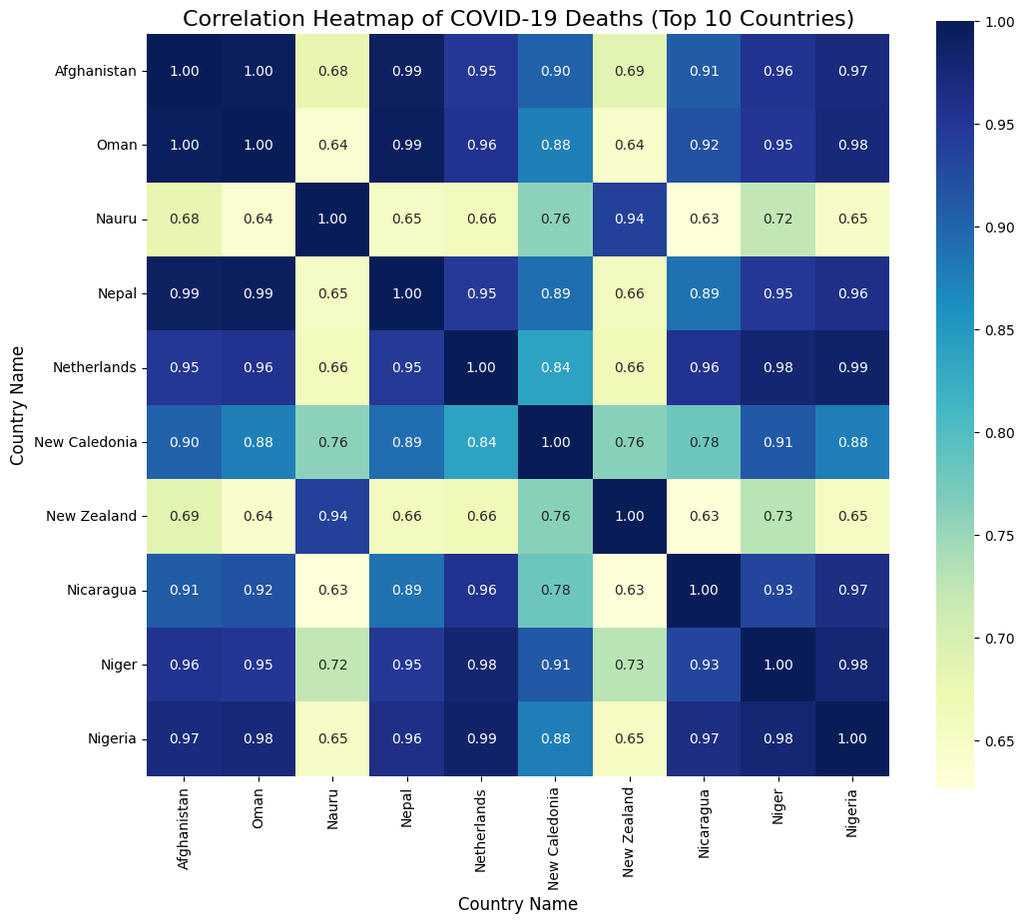

```python
print("Generating visualizations...")

print("\nVisualization 1. Calling to create correlation heatmap...")
# To Do: Call the create_corretlation_heatmap() function
create_correlation_heatmap(df)
```

```
Visualization 2. Calling to create bar chart...
Creating bar chart for top 20 countries...
```

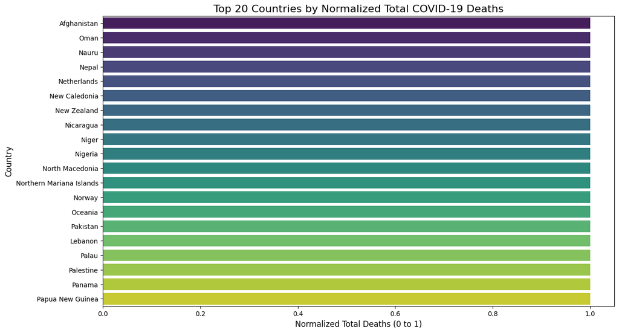

```python
print("Visualization 2. Calling to create bar chart...")
# To Do: Call the create_bar_chart() function
create_bar_chart(df)
```

```
Visualization 3. Calling to create time series chart...
Creating global time series chart...
```

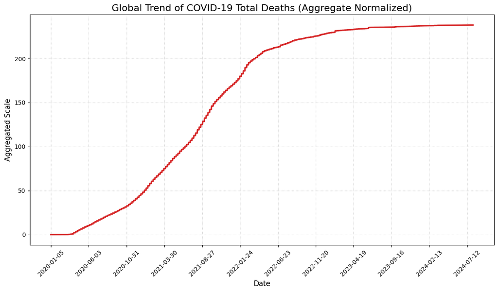

```
All visualizations have been generated, saved, and rendered.
```

```python
print("Visualization 3. Calling to create time series chart...")
# To Do: Call the create_time_series_chart() function
create_time_series_chart(df)

print("\nAll visualizations have been generated, saved, and rendered.")
```

# Part Three: Interactive Visualizations

#### Use Plotly to create two interactive visualizations:

- One visualization should allow drill-down or zoom capabilities (e.g., zoom into specific time ranges or regions).
- Another should use Overview+Detail techniques (e.g., a main chart with a small overview window).

#### Add interactive elements, such as:

- Tooltips to display additional data on hover.
- Dropdown menus or buttons to filter data dynamically.

#### Expected Output

- **Drill-Down/Zoom Chart:** A line chart of global deaths with zooming and a range slider.
- **Overview+Detail Chart:** A combined chart with an overview (total deaths globally) and a detailed view (deaths for the top 5 countries).

*Note:* For the interactive visualizations, ensure that you use the **{variable}.show()** function to call the chart to render in the output so that it can be assessed in the html output.

## Load the preprocessed dataset from Part One above

```python
# To Do: Load the cleaned/preprocessed dataset you created in Part 1 of this assignment. This dataset should be in the 'data' folder.
file_path = "data/COVID_total_deaths_preprocessed1.csv"

try:
    df_preprocessed = pd.read_csv(file_path)
    print("Preprocessed dataset loaded successfully.")
except FileNotFoundError:
    print(f"Error: The file at {file_path} was not found. Please ensure Part One was completed.")
```

```
Preprocessed dataset loaded successfully.
```

## Preview the dataset

```python
print("Dataset Preview:")
# To Do: Display the first few rows of the dataset for preview.
display(df_preprocessed.head())
```

```
Dataset Preview:
```

|  | date | World | Afghanistan | Africa | Albania | Algeria | American Samoa | Andorra | Angola | Anguilla | ... | Uruguay | Uzbekistan | Vanuatu | Vatican | Venezuela | Vietnam | Wallis and Futuna | Yemen | Zambia | Zimbabwe |
| --- | --- | --- | --- | --- | --- | --- | --- | --- | --- | --- | --- | --- | --- | --- | --- | --- | --- | --- | --- | --- | --- |
| 0 | 2020-01-05 | 0.0 | 0.0 | 0.0 | 0.0 | 0.0 | 0.0 | 0.0 | 0.0 | 0.0 | ... | 0.0 | 0.0 | 0.0 | 0.0 | 0.0 | 0.0 | 0.0 | 0.0 | 0.0 | 0.0 |
| 1 | 2020-01-06 | 0.0 | 0.0 | 0.0 | 0.0 | 0.0 | 0.0 | 0.0 | 0.0 | 0.0 | ... | 0.0 | 0.0 | 0.0 | 0.0 | 0.0 | 0.0 | 0.0 | 0.0 | 0.0 | 0.0 |
| 2 | 2020-01-07 | 0.0 | 0.0 | 0.0 | 0.0 | 0.0 | 0.0 | 0.0 | 0.0 | 0.0 | ... | 0.0 | 0.0 | 0.0 | 0.0 | 0.0 | 0.0 | 0.0 | 0.0 | 0.0 | 0.0 |
| 3 | 2020-01-08 | 0.0 | 0.0 | 0.0 | 0.0 | 0.0 | 0.0 | 0.0 | 0.0 | 0.0 | ... | 0.0 | 0.0 | 0.0 | 0.0 | 0.0 | 0.0 | 0.0 | 0.0 | 0.0 | 0.0 |
| 4 | 2020-01-09 | 0.0 | 0.0 | 0.0 | 0.0 | 0.0 | 0.0 | 0.0 | 0.0 | 0.0 | ... | 0.0 | 0.0 | 0.0 | 0.0 | 0.0 | 0.0 | 0.0 | 0.0 | 0.0 | 0.0 |

5 rows × 247 columns

## Create Visualizations

### Visualization 1: Drill-Down/Zoom Capabilities

*Hints:* Use **show()** to render your interactive chart inside the notebook in an html exportable format.

```python
def create_drill_down_chart(data):
    print("\nCreating drill-down/zoom visualization...")
    # To Do: Summing the deaths globally by date
    numerical_cols = data.select_dtypes(include=['number']).columns
    global_trend = data[numerical_cols].sum(axis=1)

    # To Do: Create an interactive time series chart with zoom capability
    fig = go.Figure()

    fig.add_trace(go.Scatter(
        x=data['date'],
        y=global_trend,
        mode='lines',
        name='Global Deaths (Normalized)',
        line=dict(color='firebrick', width=3)
    ))

    # Adding zoom capability
    fig.update_layout(
        title='Global COVID-19 Deaths: Interactive Drill-Down',
        xaxis_title='Date',
        yaxis_title='Aggregated Normalized Deaths',
        template='plotly_white',
        xaxis=dict(
            rangeslider=dict(visible=True), # This provides the "Zoom" bar at the bottom
            type='date'
        )
    )


    # To Do: Show the chart
    fig.show()
```

### Visualization 2: Overview+Detail Chart

*Hints:* Use **show()** to render your interactive chart inside the notebook in an html exportable format.

```python
def create_overview_detail_chart(data):
    print("\nCreating overview+detail visualization...")
    # To Do: Aggregating data for the top 5 countries by total deaths
    # We find the max value (total deaths) for each country and sort
    exclude_list = ['World', 'Africa', 'Asia', 'Europe', 'North America', 'South America',
                    'European Union', 'High income', 'Upper middle income', 'Lower middle income',
                    'Low income', 'Global_Sum']
    country_totals = data.drop(columns=['date'], errors='ignore').max()
    top_5_countries = country_totals.drop(labels=exclude_list, errors='ignore').sort_values(ascending=False).head(5).index.tolist()

    # To Do: Filter the dataset for the top 5 countries
    # We keep the date and the specific top 5 columns
    filtered_data = data[['date'] + top_5_countries]

    # To Do: Create an overview+detail chart
    fig = go.Figure()

    # To Do: Do the Detail portion of the chart (main chart)
    # We add a line for each of the top 5 countries
    for country in top_5_countries:
        fig.add_trace(go.Scatter(
            x=filtered_data['date'],
            y=filtered_data[country],
            mode='lines',
            name=country
        ))

    # To Do: Do the Overview portion of the chart (small chart)
    # In Plotly, the Overview is handled by adding a 'rangeslider' to the xaxis
    # To Do: Configure layout
    fig.update_layout(
        title='Overview + Detail: COVID-19 Death Trends (Top 5 Countries)',
        xaxis_title='Date',
        yaxis_title='Normalized Deaths',
        template='plotly_white',
        legend_title='Countries',
        hovermode='x unified',
        xaxis=dict(
            rangeslider=dict(
                visible=True,
                thickness=0.15 # This creates the "Overview" mini-chart at the bottom
            ),
            type='date'
        )
    )

    # To Do: Show the chart
    fig.show()
```

## Call the visualization functions

*Reminder:* For the interactive visualizations, ensure that you use the **{variable}.show()** function to call the chart to render in the output so that it can be assessed in the html output.

```python
print("Generating visualizations...")

print("\nVisualization 1. Creating Drill-Down/Zoom Capabilities...")
# To Do: Call the create_drill_down_chart() function
create_drill_down_chart(df_preprocessed)
```

```
Generating visualizations...

Visualization 1. Creating Drill-Down/Zoom Capabilities...

Creating drill-down/zoom visualization...
```

[interactive chart not shown]

```python
print("Visualization 2. Creating Overview+Detail Chart...")
# To Do: Call the create_overview_detail_chart() function

create_overview_detail_chart(df_preprocessed)
print("\nAll visualizations have been generated.")
```

[output not shown]

# Part Four: Customization and Animation

Using the original dataset `data/COVID_total_deaths.csv` (without normalization so as to ensure animation shows useful data points that are not scaled).

#### Customize the visualizations with matplotlib animation.

- A consistent theme or style (e.g., custom fonts, colors, gridlines).
- Layout optimization to ensure clarity and usability.

#### Add animation or transitions to one of the interactive visualizations

For example you can add animations to show changes over time (e.g., an animated line chart).

*Note:* For the interactive visualizations, ensure that you use the **{variable}.show()** function to call the chart to render in the output so that it can be assessed in the html output.

## Load the Dataset

```python
# To Do: Load the original dataset `data/COVID_total_deaths.csv` from the 'data' folder.
df_raw = pd.read_csv('data/COVID_total_deaths.csv')
print(f"Original dataset loaded. Shape: {df_raw.shape}")
```

[output not shown]

## Clean and Preprocess the Data

```python
def clean_data(data):
    print("\nCleaning the dataset...")

    # To Do: Remove countries with all zero deaths
    numerical_data = data.select_dtypes(include=['number'])
    cols_to_keep = numerical_data.columns[numerical_data.max() > 0].tolist()
    data_filtered = data[['date'] + cols_to_keep]

    # To Do: Remove rows (dates) with all zero deaths
    row_sums = data_filtered.select_dtypes(include=['number']).sum(axis=1)
    data_filtered = data_filtered[row_sums > 0].copy()

    # To Do: Convert 'date' column to datetime, display filtered dataset shape & return filtered data
    data_filtered['date'] = pd.to_datetime(data_filtered['date'])

    print(f"Filtered dataset shape: {data_filtered.shape}")
    return data_filtered
```

```python
# To Do: Call the clean_data() function.
df_clean_animated = clean_data(df_raw)
```

[output not shown]

## Select Top 10 Countries

```python
def select_top_countries(data):
    print("\nSelecting top 10 countries by total deaths...")

    # To Do: Calculate total deaths by country.
    country_totals = data.drop(columns=['date']).max()
## Select Top 10 Countries
    # To Do: Exclude these aggregate regions or groups
    #    "World",
    #    "Africa",
    #    "Europe",
    #    "North America",
    #    "South America",
    #    "Asia",
    #    "European Union (27)",
    #    "High-income countries",
    #    "Upper-middle-income countries",
    #    "Lower-middle-income countries"

    # To Do: Select top 10 individual countries
    exclude_list = [
        "World", "Africa", "Europe", "North America", "South America", "Asia",
        "European Union (27)", "High-income countries", "Upper-middle-income countries",
        "Lower-middle-income countries", "European Union"
    ]

    top_10_names = country_totals.drop(labels=exclude_list, errors='ignore').sort_values(ascending=False).head(10).index.tolist()

    print("\nTop 10 individual countries by total deaths:")
    # To Do: Display the top 10 individual countries
    print(top_10_names)

    # To Do: Filter the dataset for the top 10 countries
    filtered_data = data[['date'] + top_10_names].copy()

    # To Do: Aggregate data weekly (downsample)
    filtered_data.set_index('date', inplace=True)
    filtered_data = filtered_data.resample('W').max().reset_index()

    # To Do: Display the print(f"\nFiltered dataset shape after selecting. Return filtered data.
    print(f"\nFiltered dataset shape after selecting top countries: {filtered_data.shape}")
    return filtered_data
```

```python
# To Do: Call select_top_countries()
df_top_10 = select_top_countries(df_clean_animated)
```

[output not shown]

## Prepare Data for Animation

```python
print("Preparing data for animation...")
# To Do: Melt the data for easier plotting
df_melted = df_top_10.melt(id_vars=['date'],
                           var_name='Country',
                           value_name='Total_Deaths')
#Deaths are treated as floats/ints for the animation scale
df_melted['Total_Deaths'] = df_melted['Total_Deaths'].fillna(0)
```

```python
print("Data prepared successfully!")
# To Do: Display melted data
display(df_melted.head(10))
```

[output not shown]

## Create the Matplotlib Animation

```python
print("Creating the animation...ignore static output")
# To Do: Initialize the plot
fig, ax = plt.subplots(figsize=(12, 7))
lines = []
countries = df_top_10.columns[1:]

# To Do: Set the axis limits and labels
ax.set_xlim(df_top_10['date'].min(), df_top_10['date'].max())
# Set Y-limit to slightly above the global maximum death count for the top country
ax.set_ylim(0, df_top_10[countries].max().max() * 1.05)

ax.set_title('Growth of COVID-19 Total Deaths (Top 10 Countries)', fontsize=16)
ax.set_xlabel('Date', fontsize=12)
ax.set_ylabel('Total Deaths', fontsize=12)
ax.grid(True, linestyle='--', alpha=0.6)

# Create a line object for each country
for country in countries:
    line, = ax.plot([], [], label=country, lw=2)
    lines.append(line)

ax.legend(loc='upper left', bbox_to_anchor=(1, 1))
```

### Function to initialize the animation

```python
def init():
    # To Do: Create a for loop here to initialize lines values. Return lines values.
    for line in lines:
        line.set_data([], [])
    return lines
```

### Function to update the animation frame-by-frame

```python
def update(frame):
    # To Do: Update the animation frame-by-frame.
    current_date = df_top_10['date'].iloc[:frame+1]

    for i, country in enumerate(countries):
        # Get the cumulative deaths up to the current frame for this country
        current_deaths = df_top_10[country].iloc[:frame+1]
        lines[i].set_data(current_date, current_deaths)

    return lines
```

### Create the animation

*Hints:* Use **FuncAnimation()** to initate the animation visualization. Use **HTML({variable}.to_jshtml())** to render your animation inside the notebook in an html exportable format.

```python
# To Do: Call FuncAnimation() to create the animation -
#        interval=200 means each frame witll last 200 ms (0.2 sec). Small values make the animation faster

ani = FuncAnimation(fig, update, frames=len(df_top_10),
                    init_func=init, blit=True, interval=200)


# To Do: Show the animation
plt.close()
display(HTML(ani.to_jshtml()))
```

[output not shown]